# Industry 4.0 의 중심, BigData

Data Processing Based Python @ [FB / jskim.kr](https://www.facebook.com/jskim.kr), [김진수](bigpycraft@gmail.com)

## TextBook. 파이썬을 이용한 웹크롤링과 스크레이핑

> 데이터 수집과 분석을 위한 실전 가이드  
> **INDEX.**

> **APPENDIX**

## 크롤링/스크레이핑 실전과 데이터 활용

> - 데이터 세트 추출과 활용
> - API로 데이터 수집하고 활용
> - 시계열 데이터 수집하고 활용
> - 열린 데이터 수집과 활용
> - 웹 페이지 자동 조작
> - 자바스크립트를 이용한 페이지 스크레이핑
> - 추출한 데이터 활용

```python
import os
from os.path import exists

def make_dir(dir_name):
    ''' 디렉토리 생성 '''

    if not exists(dir_name):
        os.mkdir(dir_name)
        msg = "{} 디렉토리를 생성하였습니다!".format(dir_name)
    else:
        msg = "{} 디렉토리가 이미 존재합니다!".format(dir_name)

    return msg
```

### 데이터 세트 추출과 활용

> [Index of /kowiki/](https://dumps.wikimedia.org/kowiki/)
> - 위키백과 데이터 세트 다운로드
> - 위키백과 데이터 세트에서 문장 추출

#### 위키백과 데이터 세트 다운로드

```python
make_dir('data/dataset')
```

```
'data/dataset 디렉토리가 이미 존재합니다!'
```

```python
# ! wget https://dumps.wikimedia.org/kowiki/20181101/ -q -O -
```

```python
! wget https://dumps.wikimedia.org/kowiki/20181101/ -O ./data/dataset/kowiki-2018110-index.html
```

```
--2018-11-15 02:27:31--  https://dumps.wikimedia.org/kowiki/20181101/
Resolving dumps.wikimedia.org (dumps.wikimedia.org)... 208.80.154.7
Connecting to dumps.wikimedia.org (dumps.wikimedia.org)|208.80.154.7|:443... connected.
HTTP request sent, awaiting response... 200 OK
Length: 15049 (15K) [text/html]
Saving to: './data/dataset/kowiki-2018110-index.html'

     0K .......... ....                                       100% 1.31M=0.01s

2018-11-15 02:27:33 (1.31 MB/s) - './data/dataset/kowiki-2018110-index.html' saved [15049/15049]
```

```python
from bs4 import BeautifulSoup
import pandas as pd

filepath = './data/dataset/kowiki-2018110-index.html'
with open(filepath, encoding='utf-8') as fp:
    soup = BeautifulSoup(fp, 'lxml')

soup.title
```

```
<title>kowiki dump progress on 20181101</title>
```

```python
done_tags = soup.find_all('li', 'done')
len(done_tags)
```

```
31
```

```python
done_tag = done_tags[0]
done_tag
```

```
<li class="done"><span class="updates">2018-11-02 16:02:35</span> <span class="status">done</span> <span class="title">Articles, templates, media/file descriptions, and primary meta-pages, in multiple bz2 streams, 100 pages per stream</span><ul><li class="file"><a href="/kowiki/20181101/kowiki-20181…
<li class="file"><a href="/kowiki/20181101/kowiki-20181101-pages-articles-multistream-index.txt.bz2">kowiki-20181101-pages-articles-multistream-index.txt.bz2</a> 10.5 MB</li></ul></li>
```

```python
updates = done_tag.find('span', 'updates').get_text()
updates
```

```
'2018-11-02 16:02:35'
```

```python
title = done_tag.find('span', 'title').get_text()
title
```

```
'Articles, templates, media/file descriptions, and primary meta-pages, in multiple bz2 streams, 100 pages per stream'
```

```python
file_tags = done_tag.find_all('li', 'file')
files = []
for file_tag in file_tags:
    file_dict = {}
    file_name = file_tag.find('a').get_text()
    file_link = file_tag.find('a').get('href')

    file_dict['FileName'] = file_name
    file_dict['FileLink'] = file_link
    files.append(file_dict)

files
```

```
[{'FileLink': '/kowiki/20181101/kowiki-20181101-pages-articles-multistream.xml.bz2',
  'FileName': 'kowiki-20181101-pages-articles-multistream.xml.bz2'},
 {'FileLink': '/kowiki/20181101/kowiki-20181101-pages-articles-multistream-index.txt.bz2',
  'FileName': 'kowiki-20181101-pages-articles-multistream-index.txt.bz2'}]
```

```python
from bs4 import BeautifulSoup
import pandas as pd

def getKowikiInfos(filepath):

    with open(filepath, encoding='utf-8') as fp:
        soup = BeautifulSoup(fp, 'lxml')

    Updates  = []
    Title    = []
    FileList = []   # 파일이름 리스트
    Files    = []   # 파일상세 리스트

    done_tags = soup.find_all('li', 'done')

    for done_tag in done_tags:
        # 등록날짜
        updates = done_tag.find('span', 'updates').get_text()

        # 제목
        title = done_tag.find('span', 'title').get_text()

        # 파일리스트
        file_tags = done_tag.find_all('li', 'file')
        files = []
        filenames = []
        for file_tag in file_tags:
            file_dict = {}
            file_name = file_tag.find('a').get_text()
            file_link = file_tag.find('a').get('href')

            file_dict['FileName'] = file_name
            file_dict['FileLink'] = file_link
            files.append(file_dict)

            filenames.append(file_name)

        Updates.append(updates)
        Title.append(title)
        FileList.append(tuple(filenames))
        Files.append(files)

    kokiwi_df = pd.DataFrame({ 'Updates'  : Updates,
                               'Title'    : Title,
                               'FileList' : FileList,
                               'FileInfo' : Files },
                               columns = ['Updates', 'Title', 'FileList', 'FileInfo'])

    return kokiwi_df
```

```python
filepath = './data/dataset/kowiki-2018110-index.html'
kokiwi_df = getKowikiInfos(filepath)
```

```python
kokiwi_df.head()
```

|  | Updates | Title | FileList | FileInfo |
| --- | --- | --- | --- | --- |
| 0 | 2018-11-02 16:02:35 | Articles, templates, media/file descriptions, ... | (kowiki-20181101-pages-articles-multistream.xm... | [{'FileName': 'kowiki-20181101-pages-articles-... |
| 1 | 2018-11-06 05:30:17 | All pages with complete edit history (.7z) | (kowiki-20181101-pages-meta-history.xml.7z,) | [{'FileName': 'kowiki-20181101-pages-meta-hist... |
| 2 | 2018-11-06 00:03:51 | All pages with complete page edit history (.bz2) | (kowiki-20181101-pages-meta-history.xml.bz2,) | [{'FileName': 'kowiki-20181101-pages-meta-hist... |
| 3 | 2018-11-03 21:35:06 | Log events to all pages and users. | (kowiki-20181101-pages-logging.xml.gz,) | [{'FileName': 'kowiki-20181101-pages-logging.x... |
| 4 | 2018-11-03 00:39:38 | All pages, current versions only. | (kowiki-20181101-pages-meta-current.xml.bz2,) | [{'FileName': 'kowiki-20181101-pages-meta-curr... |

```python
kokiwi_df['FileList'][0]
```

```
('kowiki-20181101-pages-articles-multistream.xml.bz2',
 'kowiki-20181101-pages-articles-multistream-index.txt.bz2')
```

#### 자연어 처리를 사용한 빈출 단어 추출

> 형태소 분석 : 자연어 처리의 기본 기술
> - 주어진 단어를 형태소라는 최소 단어로 분할해서 품사 등을 판별하는 것을 의미
> - 형태소 분석 라이브러리 : KoNLLPy, 파이썬 한국어 NLP
>   - 한나눔
>   - 꼬꼬마
>   - Komoran
>   - MeCab
>   - 트위트

#### c5-01_konlpy_sample

> KoNLPy로 형태소 분석

```python
from konlpy.tag import Kkma

kkma   = Kkma()
malist = kkma.pos("아버지 가방에 들어가신다.")
malist
```

```
[('아버지', 'NNG'),
 ('가방', 'NNG'),
 ('에', 'JKM'),
 ('들어가', 'VV'),
 ('시', 'EPH'),
 ('ㄴ다', 'EFN'),
 ('.', 'SF')]
```

#### 문장에서 빈출 단어 추출

#### c5-02_word_frequency

> 위키백과 문장에서 빈출 단어 추출

```
%%writefile  ./modules/word_frequency.py

import sys
import os
from glob import glob
from collections import Counter
from konlpy.tag import Kkma

def main():
    """
    명령라인 매개변수로 지정한
    디렉터리 내부의 파일을 읽어 들이고
    빈출 단어를 출력합니다.
    """
    # 명령어의 첫 번째 매개변수로
    # WikiExtractor의 출력 디렉터리를 지정합니다.
    input_dir = sys.argv[1]
    kkma = Kkma()
    # 단어의 빈도를 저장하기 위한 Counter 객체를 생성합니다.
    # Counter 클래스는 dict를 상속받는 클래스입니다.
    frequency = Counter()
    count_proccessed = 0
    # glob()으로 와일드카드 매치 파일 목록을 추출하고
    # 매치한 모든 파일을 처리합니다.
    for path in glob(os.path.join(input_dir, '*', 'wiki_*')):
        print('Processing {0}...'.format(path), file=sys.stderr)
        # 파일을 엽니다.
        with open(path) as file:
            # 파일 내부의 모든 기사에 반복을 돌립니다.
            for content in iter_docs(file):
                # 페이지에서 명사 리스트를 추출합니다.
                tokens = get_tokens(kkma, content)
                # Counter의 update() 메서드로 리스트 등의 반복 가능 객체를 지정하면
                # 리스트에 포함된 값의 출현 빈도를 세어줍니다.
                frequency.update(tokens)
                # 10,000개의 글을 읽을 때마다 간단하게 출력합니다.
                count_proccessed += 1
                if count_proccessed % 10000 == 0:
                    print('{0} documents were processed.'
                        .format(count_proccessed),file=sys.stderr)

    # 모든 기사의 처리가 끝나면 상위 30개의 단어를 출력합니다
    for token, count in frequency.most_common(30):
        print(token, count)

def iter_docs(file):
    """
    파일 객체를 읽어 들이고
    기사의 내용(시작 태그 <doc>와 종료 태그 </doc> 사이의 텍스트)를 꺼내는
    제너레이터 함수
    """
    for line in file:
        if line.startswith('<doc '):
            # 시작 태그가 찾아지면 버퍼를 초기화합니다.
            buffer = []
        elif line.startswith('</doc>'):
            # 종료 태그가 찾아지면 버퍼의 내용을 결합한 뒤 yield합니다.
            content = ''.join(buffer)
            yield content
        else:
            # 시작 태그/종료 태그 이외의 줄은 버퍼에 추가합니다.
            buffer.append(line)

def get_tokens(kkma, content):
    """
    문장 내부에 출현한 명사 리스트를 추출하는 함수
    """
    # 명사를 저장할 리스트입니다.
    tokens = []
    node = kkma.pos(content)
    for (taeso, pumsa) in node:
        # 고유 명사와 일반 명사만 추출합니다.
        if pumsa in ('NNG', 'NNP'):
            tokens.append(taeso)
    return tokens

if __name__ == '__main__':
    main()
```

```python
%%writefile  word_frequency.py
# %%writefile  ./modules/word_frequency.py
import sys
import os
from glob import glob
from collections import Counter
from konlpy.tag import Kkma

def main():
    """
    명령라인 매개변수로 지정한
    디렉터리 내부의 파일을 읽어 들이고
    빈출 단어를 출력합니다.
    """
    # 명령어의 첫 번째 매개변수로
    # WikiExtractor의 출력 디렉터리를 지정합니다.
    input_dir = sys.argv[1]
    print('input_dir :', input_dir)
    kkma = Kkma()

    # 단어의 빈도를 저장하기 위한 Counter 객체를 생성합니다.
    # Counter 클래스는 dict를 상속받는 클래스입니다.
    frequency = Counter()
    count_proccessed = 0

    # glob()으로 와일드카드 매치 파일 목록을 추출하고
    # 매치한 모든 파일을 처리합니다.
    # print('before for :', glob(os.path.join(input_dir, 'kowiki-*')))
    # for path in glob(os.path.join(input_dir, '*', 'wiki_*')):
    for path in glob(os.path.join(input_dir, 'kowiki-*')):
        print('path :', path)
        print('Processing {0}...'.format(path), file=sys.stderr)

        # 파일을 엽니다.
        with open(path) as file:
            # 파일 내부의 모든 기사에 반복을 돌립니다.
            for content in iter_docs(file):
                # 페이지에서 명사 리스트를 추출합니다.
                tokens = get_tokens(kkma, content)

                # Counter의 update() 메서드로 리스트 등의 반복 가능 객체를 지정하면
                # 리스트에 포함된 값의 출현 빈도를 세어줍니다.
                frequency.update(tokens)

                # 10,000개의 글을 읽을 때마다 간단하게 출력합니다.
                count_proccessed += 1
                if count_proccessed % 10000 == 0:
                    print('{0} documents were processed.'
                        .format(count_proccessed),file=sys.stderr)

    # 모든 기사의 처리가 끝나면 상위 30개의 단어를 출력합니다
    for token, count in frequency.most_common(30):
        print(token, count)


def iter_docs(file):
    """
    파일 객체를 읽어 들이고
    기사의 내용(시작 태그 <doc>와 종료 태그 </doc> 사이의 텍스트)를 꺼내는
    제너레이터 함수
    """
    for line in file:
        if line.startswith('<doc '):
            # 시작 태그가 찾아지면 버퍼를 초기화합니다.
            buffer = []
        elif line.startswith('</doc>'):
            # 종료 태그가 찾아지면 버퍼의 내용을 결합한 뒤 yield합니다.
            content = ''.join(buffer)
            yield content
        else:
            # 시작 태그/종료 태그 이외의 줄은 버퍼에 추가합니다.
            buffer.append(line)


def get_tokens(kkma, content):
    """
    문장 내부에 출현한 명사 리스트를 추출하는 함수
    """
    # 명사를 저장할 리스트입니다.
    tokens = []
    node = kkma.pos(content)
    for (taeso, pumsa) in node:
        # 고유 명사와 일반 명사만 추출합니다.
        if pumsa in ('NNG', 'NNP'):
            tokens.append(taeso)
    return tokens

if __name__ == '__main__':
    main()
```

```
Overwriting word_frequency.py
```

```python
make_dir('./data/result')
```

```
'./data/result 디렉토리가 이미 존재합니다!'
```

```python
! python word_frequency.py .\data\dataset
```

```
input_dir : .\data\dataset
path : .\data\dataset\kowiki-2018110-index.html
```

```
Processing .\data\dataset\kowiki-2018110-index.html...
Traceback (most recent call last):
  File "word_frequency.py", line 88, in <module>
    main()
  File "word_frequency.py", line 36, in main
    for content in iter_docs(file):
  File "word_frequency.py", line 71, in iter_docs
    buffer.append(line)
UnboundLocalError: local variable 'buffer' referenced before assignment
```

### API로 데이터 수집하고 활용

> - 트위트에서 데이터 수집
> - 유튜브에서 데이터 수집

### 트위터에서 데이터 수집

> 데이터 수집에 사용되는 2가지 API
> - REST API :  
>   - HTTP 요청을 전송하면 HTTP 응답을 반환하는 RESTful 형태로 트윗 또는 사용자 정보를 추출,  
>   - 호출 횟수 제한이 굉장히 엄격  
>   - 한 사용자당 15분에 15회만 호출 제한이 있으므로, 대규모 데이터수집에는 좋지 않다.
> - Streaming API :  
>   - 한번의 요청을 보내면 서버와의 연결(컨넥션)을 유지하고,  
>   - 새로운 데이터가 추가될 때마다 서버가 데이터를 전송해주는 푸시 형태  
>   - HTTP 요청을 보냈을때 연결을 확립한 상태로 두고 서버에서 메시지를 계속 전송받는 형태

cf. RESTful : https://meetup.toast.com/posts/92

> - REST 구성  
>   - 자원(RESOURCE) - URI  
>   - 행위(Verb) - HTTP METHOD  
>   - 표현(Representations)
> - REST 특징  
>   1) Uniform (유니폼 인터페이스)  
>   2) Stateless (무상태성)  
>   3) Cacheable (캐시 가능)  
>   4) Self-descriptiveness (자체 표현 구조)  
>   5) Client - Server 구조  
>   6) 계층형 구조  
>   [참고] HTTP METHOD의 알맞은 역할  
>   POST, GET, PUT, DELETE 이 4가지의 Method를 가지고 CRUD를 할 수 있습니다.

#### 트위터 API 인증

> OAuth 1.0a 인증 필요 (아래 4가지 모두 필요)
> - 애플리케니션 단위 발행  
>   - Cousumer Key  
>   - Consuber Secret
> - 사용자 단위 발행  
>   - Access Token  
>   - Access Token Secret

> 트위터 인증 정보를 위해 애플리케이션 등록
> - [**[ 애플리케이션 관리 화면 ]**](https://apps.twitter.com/) 에 트위터 계정으로 로그인
> - "Create New App" 버튼 클릭
> - 이름, 설명, 웹사이트 를 입력하고 사용약관 동의하면 애플리케이션이 생성된다.
> - "Keys and Access Tokens" 링크 클릭 후, 생성된 4개의 키 값을 저장

#### Twitter Key 값 확인

> key값 확인 : https://apps.twitter.com/app/13434937/keys

#### Application Settings

> Keep the "Consumer Secret" a secret. This key should never be human-readable in your application.
> - Consumer Key (API Key) : oWmNK＊＊＊＊＊＊＊＊＊＊＊
> - Consumer Secret (API Secret) : pM3MNxxxxxxxxxxxxxxxxxxxxxxxxxxxxxxxxxxxxxxxxxxxxxxx

#### Your Access Token

> This access token can be used to make API requests on your own account's behalf. Do not share your access token secret with anyone.
> - Access Token : 15625xxxxxxxxxxxxxxxxxxxxxxxxxxxxxxxxxxxxxxxxxxxxxxx
> - Access Token Secret : aeFqGxxxxxxxxxxxxxxxxxxxxxxxxxxxxxxxxxxxxxxxxxx

```python
# Twitter Application Settings
CONSUMER_KEY        = "oWmNK********************"
CONSUMER_SECRET     = "pM3MN*********************************************"

# Twitter Your Access Token
ACCESS_TOKEN        = "15625*********************************************"
ACCESS_TOKEN_SECRET = "aeFqG****************************************"
```

#### c5-03_rest_api_with_requests_oauthlib

> Requests OAuthLib 를 이용한 타임라인 추출
> - 인증 정보를 사용해 OAuth1Session 객체를 생성
> - API 응답이 JSON 형식의 문자열이므로 response.json()으로 파싱
> - status는 트윗(Twitter API에서는 Status)를 나타내는 dict

```python
from bigpycraft.oauth import twitter_key
from requests_oauthlib import OAuth1Session
import os

# 환경변수에서 인증 정보를 추출합니다.
# CONSUMER_KEY        = os.environ['CONSUMER_KEY']
# CONSUMER_SECRET     = os.environ['CONSUMER_SECRET']
# ACCESS_TOKEN        = os.environ['ACCESS_TOKEN']
# ACCESS_TOKEN_SECRET = os.environ['ACCESS_TOKEN_SECRET']

CONSUMER_KEY        = twitter_key.CONSUMER_KEY
CONSUMER_SECRET     = twitter_key.CONSUMER_SECRET
ACCESS_TOKEN        = twitter_key.ACCESS_TOKEN
ACCESS_TOKEN_SECRET = twitter_key.ACCESS_TOKEN_SECRET


# 인증 정보를 사용해 OAuth1Session 객체를 생성합니다.
twitter = OAuth1Session(CONSUMER_KEY,
                        client_secret=CONSUMER_SECRET,
                        resource_owner_key=ACCESS_TOKEN,
                        resource_owner_secret=ACCESS_TOKEN_SECRET)

# 사용자의 타임라인을 추출합니다.
response = twitter.get('https://api.twitter.com/1.1/statuses/home_timeline.json')

# API 응답이 JSON 형식의 문자열이므로 response.json()으로 파싱합니다.
# status는 트윗(Twitter API에서는 Status라고 부릅니다)를 나타내는 dict입니다.
for status in response.json():
    # 사용자 이름과 트윗을 출력합니다.
    print('@' + status['user']['screen_name'], status['text'])
```

```
@Medium RT @EFF: A million Europeans called for changes to the #CopyrightDirective to prevent censorship and surveillance: where do we stand now? h…
@Medium Some wealthy liberals now appear to be okay with dipping their toes in socially regressive ideas. Don't ignore them… https://t.co/QWmUIl2jbq
@congjee RT @kuky___kuky: 9595쇼가 딱 짚어줬네!
노벨 평화상 후보 접수가 지난 2월에 마감이라 문프님, 트통 전혀 상관 없는데
김어준이 뉴스공장에서 노벨 평화상은 트통! 우리는 평화! 이런 뻘소리.
그걸 들은 청취자들은 그렇구나~ 하며 휩쓸…
@congjee RT @bleuchatte: 대우조선해양, 3분기 연속 흑자..＂경영정상화 문턱＂(종합) https://t.co/9bJu21j3Md
굿뉴스~~!!
@congjee 황교익 선생에게 글삭 당하고 차단 당해 화가 난 전직 검사 | Daum카페 https://t.co/OoVmHCcWo7
@NASA LAUNCH UPDATE: Due to unfavorable weather, @northropgrumman’s cargo launch to the @Space_Station has been postponed… https://t.co/mOJePQ5bTY
@Medium Welcome to open enrollment season! If you have no idea which health plan to choose, don't get too down on yourself:… https://t.co/UMvwrFpJic
@NASA LIVE NOW: Get an update from experts on tomorrow’s 4:49am ET cargo launch to the @Space_Station aboard… https://t.co/FdBIlqLtBd
@Medium Happiness is fleeting. Sorry, but that's just science: It's called the "hedonic treadmill," and while evolution rea… https://t.co/8XFf8cygXQ
@NASA What’s the status of tomorrow’s 4:49am ET cargo launch to the International @Space_Station? Tune in today at 11am E… https://t.co/jkVekXfaoi
@Medium Tim Wu: "We’ve had periods in this country where antitrust fervor was very strong. Both Democrats and Republicans h… https://t.co/EVUq25fCRt
@timoreilly RT @byron_auguste: Questions for Georgia state officials:
1. Why would you arrest an elected state senator at a protest rally?
2. Why is a…
@timoreilly RT @PennieBrian: POWERFUL (even scary) message on "living in the moment" from @timoreilly via @tferriss book "Tribe of Mentors" https://t.c…
@BTS_ARMY And now, A.R.M.Y R U READY?

Burn The Stage : The Movie is almost here!  #BTS @BTS_twt @bts_bighit @BigHitEnt

B… https://t.co/QEoO4mgsof
@BTS_ARMY Thank you, Tokyo! Thanks to all who have spent 2 beautiful days with us at Tokyo Dome &amp; to all at home watching ove… https://t.co/obiTXqiCV6
@Medium Online scammers are getting more creative. Here are five recent attacks to be on the lookout for. https://t.co/wC9RNuyibJ
@BTS_ARMY A.R.M.Y! 東京ドームでこの2日間を私たちと過ごしてくれて、そして愛をありがとうございます！
いつも健康でいてください。またすぐに会いましょう！💜💜💜 @BTS_twt @bts_bighit… https://t.co/SHAkH5Zl93
@BTS_ARMY RT @BTS_jp_official: #BTS WORLD STUDIO ‘LOVE YOURSELF’ ~JAPAN EDITION~ 東京ドーム2日目！
今日も幸せにしてくれてあざっす♪
これから僕たちがもっとハッピーにしてあげますね〜ムラサキするよ💜 https:…
```

#### c5-04_rest_api_with_tweepy

> tweepy 를 이용한 타임라인 추출
> - Requests-OAuthlib을 사용한 코드와 비교하면 전체적인 흐름이 비스
> - 다른점은 REST API의 URL 지정이 home_timeline() 메소드로로 추상화
> - 트윗을 나타내는 객체가 dict가 아니라 Tweepy의 Status 객체이다

```python
# ! pip install tweepy
```

```python
import os
import tweepy

# 환경변수에서 인증 정보를 추출합니다.
# CONSUMER_KEY = os.environ['CONSUMER_KEY']
# CONSUMER_SECRET = os.environ['CONSUMER_SECRET']
# ACCESS_TOKEN = os.environ['ACCESS_TOKEN']
# ACCESS_TOKEN_SECRET = os.environ['ACCESS_TOKEN_SECRET']
CONSUMER_KEY        = twitter_key.CONSUMER_KEY
CONSUMER_SECRET     = twitter_key.CONSUMER_SECRET
ACCESS_TOKEN        = twitter_key.ACCESS_TOKEN
ACCESS_TOKEN_SECRET = twitter_key.ACCESS_TOKEN_SECRET

# 인증 정보를 설정합니다.
auth = tweepy.OAuthHandler(CONSUMER_KEY, CONSUMER_SECRET)
auth.set_access_token(ACCESS_TOKEN, ACCESS_TOKEN_SECRET)

# API 클라이언트를 생성합니다.
api = tweepy.API(auth)

# 사용자의 타임라인을 추출합니다.
public_tweets = api.home_timeline()

for status in public_tweets:
    # 사용자 이름과 트윗을 출력합니다.
    print('@' + status.user.screen_name, status.text)
```

```
@Medium RT @EFF: A million Europeans called for changes to the #CopyrightDirective to prevent censorship and surveillance: where do we stand now? h…
@Medium Some wealthy liberals now appear to be okay with dipping their toes in socially regressive ideas. Don't ignore them… https://t.co/QWmUIl2jbq
@congjee RT @kuky___kuky: 9595쇼가 딱 짚어줬네!
노벨 평화상 후보 접수가 지난 2월에 마감이라 문프님, 트통 전혀 상관 없는데
김어준이 뉴스공장에서 노벨 평화상은 트통! 우리는 평화! 이런 뻘소리.
그걸 들은 청취자들은 그렇구나~ 하며 휩쓸…
@congjee RT @bleuchatte: 대우조선해양, 3분기 연속 흑자..＂경영정상화 문턱＂(종합) https://t.co/9bJu21j3Md
굿뉴스~~!!
@congjee 황교익 선생에게 글삭 당하고 차단 당해 화가 난 전직 검사 | Daum카페 https://t.co/OoVmHCcWo7
@NASA LAUNCH UPDATE: Due to unfavorable weather, @northropgrumman’s cargo launch to the @Space_Station has been postponed… https://t.co/mOJePQ5bTY
@Medium Welcome to open enrollment season! If you have no idea which health plan to choose, don't get too down on yourself:… https://t.co/UMvwrFpJic
@NASA LIVE NOW: Get an update from experts on tomorrow’s 4:49am ET cargo launch to the @Space_Station aboard… https://t.co/FdBIlqLtBd
@Medium Happiness is fleeting. Sorry, but that's just science: It's called the "hedonic treadmill," and while evolution rea… https://t.co/8XFf8cygXQ
@NASA What’s the status of tomorrow’s 4:49am ET cargo launch to the International @Space_Station? Tune in today at 11am E… https://t.co/jkVekXfaoi
@Medium Tim Wu: "We’ve had periods in this country where antitrust fervor was very strong. Both Democrats and Republicans h… https://t.co/EVUq25fCRt
@timoreilly RT @byron_auguste: Questions for Georgia state officials:
1. Why would you arrest an elected state senator at a protest rally?
2. Why is a…
@timoreilly RT @PennieBrian: POWERFUL (even scary) message on "living in the moment" from @timoreilly via @tferriss book "Tribe of Mentors" https://t.c…
@BTS_ARMY And now, A.R.M.Y R U READY?

Burn The Stage : The Movie is almost here!  #BTS @BTS_twt @bts_bighit @BigHitEnt

B… https://t.co/QEoO4mgsof
@BTS_ARMY Thank you, Tokyo! Thanks to all who have spent 2 beautiful days with us at Tokyo Dome &amp; to all at home watching ove… https://t.co/obiTXqiCV6
@Medium Online scammers are getting more creative. Here are five recent attacks to be on the lookout for. https://t.co/wC9RNuyibJ
@BTS_ARMY A.R.M.Y! 東京ドームでこの2日間を私たちと過ごしてくれて、そして愛をありがとうございます！
いつも健康でいてください。またすぐに会いましょう！💜💜💜 @BTS_twt @bts_bighit… https://t.co/SHAkH5Zl93
@BTS_ARMY RT @BTS_jp_official: #BTS WORLD STUDIO ‘LOVE YOURSELF’ ~JAPAN EDITION~ 東京ドーム2日目！
今日も幸せにしてくれてあざっす♪
これから僕たちがもっとハッピーにしてあげますね〜ムラサキするよ💜 https:…
```

#### c5-05_streaming_api_with_tweepy

> Tweepy 로 Streaming API 사용
> - 연결 확립한 상태로 메시지 계속 전송
> - 각 메시지는 줄바꿈 코드 CRLF로 구분
> - 메시지는 대부분 트윗을 나타내는 JSON 형식의 문자열
> - 트윗 이외의 연결을 유지하기 위한 공백과 메타 정보도 전송된다.

```
import os
import tweepy

# 환경변수에서 인증 정보를 추출합니다.
# CONSUMER_KEY = os.environ['CONSUMER_KEY']
# CONSUMER_SECRET = os.environ['CONSUMER_SECRET']
# ACCESS_TOKEN = os.environ['ACCESS_TOKEN']
# ACCESS_TOKEN_SECRET = os.environ['ACCESS_TOKEN_SECRET']
CONSUMER_KEY        = twitter_key.CONSUMER_KEY
CONSUMER_SECRET     = twitter_key.CONSUMER_SECRET
ACCESS_TOKEN        = twitter_key.ACCESS_TOKEN
ACCESS_TOKEN_SECRET = twitter_key.ACCESS_TOKEN_SECRET

# 인증 정보를 설정합니다.
auth = tweepy.OAuthHandler(CONSUMER_KEY, CONSUMER_SECRET)
auth.set_access_token(ACCESS_TOKEN, ACCESS_TOKEN_SECRET)

class MyStreamListener(tweepy.StreamListener):
    """
    Streaming API로 추출한 트윗을 처리하는 클래스입니다.
    """
    def on_status(self, status):
        """
        트윗을 받을 때 호출되는 메서드
        매개변수로 트윗을 나타내는 Status 객체가 전달됩니다.
        """
        print('@' + status.author.screen_name, status.text)

# 인증 정보와 StreamListener를 지정해서 Stream 객체를 추출합니다.
stream = tweepy.Stream(auth, MyStreamListener())

# 공개돼 있는 트윗을 샘플링한 스트림을 받습니다.
# 키워드 매개변수인 languages로 한국어 트윗만 추출합니다
stream.sample(languages=['ko'])
```

```python
import os
import tweepy

# 환경변수에서 인증 정보를 추출합니다.
# CONSUMER_KEY = os.environ['CONSUMER_KEY']
# CONSUMER_SECRET = os.environ['CONSUMER_SECRET']
# ACCESS_TOKEN = os.environ['ACCESS_TOKEN']
# ACCESS_TOKEN_SECRET = os.environ['ACCESS_TOKEN_SECRET']
CONSUMER_KEY        = twitter_key.CONSUMER_KEY
CONSUMER_SECRET     = twitter_key.CONSUMER_SECRET
ACCESS_TOKEN        = twitter_key.ACCESS_TOKEN
ACCESS_TOKEN_SECRET = twitter_key.ACCESS_TOKEN_SECRET

# 인증 정보를 설정합니다.
auth = tweepy.OAuthHandler(CONSUMER_KEY, CONSUMER_SECRET)
auth.set_access_token(ACCESS_TOKEN, ACCESS_TOKEN_SECRET)

class MyStreamListener(tweepy.StreamListener):
    """
    Streaming API로 추출한 트윗을 처리하는 클래스입니다.
    """
    def on_status(self, status):
        """
        트윗을 받을 때 호출되는 메서드
        매개변수로 트윗을 나타내는 Status 객체가 전달됩니다.
        """
        print('@' + status.author.screen_name, status.text)

# 인증 정보와 StreamListener를 지정해서 Stream 객체를 추출합니다.
stream = tweepy.Stream(auth, MyStreamListener())

# 공개돼 있는 트윗을 샘플링한 스트림을 받습니다.
# 키워드 매개변수인 languages로 한국어 트윗만 추출합니다
stream.sample(languages=['ko'])
# stream.sample(languages=['en'])
```

[output not shown]

[output cut: 113 more lines]

[output not shown]

[output not shown]

[output cut: 58 more lines]

[output not shown]

### 유튜브에서 동영상 정보 수집

> Youtube Data API 버전 v3
> - API로 동영상 업로드, 댓글 드의 처리하려면 OAuth 2.0 으로 인증해야 한다.
> - 동영상 검색 또는 채널 내용 확인 등의 API는 API키로만 할 수 있다.
> - 참고로 API로 추출할 수 있는 것은 동영상과 관련된 메타데이터 뿐이다.

#### API 키 추출

> API 키를 추출하려면 구글 계정이 필요
> - 구글 계정으로 로그인한 상태에서 [**[ Googl API Console ]**](https://console.developers.google.com/)에 들어가 새로운 프로젝트 생성
> - Google API Consolo은 리소스를 프로젝트 단위로 관리
> - API > 라이브러리 > YouTube Data API v3 에서, [사용 설정] 클릭
> - [ 사용자 인증 정보 ] → [ API 키 ]를 눌러서 API키 를 생성
> - 생성할 키의 종류를 [ 서버 키 ] 로 선택하고, 적당한 이름을 설정
> - 키가 생성되면 API키가 출력되는데, 이를 복사해 둘 것!!

```python
from bigpycraft.oauth import youtube_key

YOUTUBE_API_KEY = "AIzaSy*********************************"
YOUTUBE_API_KEY = youtube_key.API_KEY
```

#### curl 명령어로 Youtube Data API 사용

> - Youtube Data API는 REST 형식의 간단한 API
> - 간단한 URL을 조합해서 HTTP 요청을 보내면 JSON 형식으로 응답한다.

#### Googld API Client for Python 사용

> - Youtube Data API는 간단한 REST API 이므로 Request 같은 라이브러리를 사용해도 문제없이 사용가능하다.
> - 다만 구글 API를 범용적으로 사용할 때 Google API Client for Python을 사용하면 편리하다.

#### c5-07_search_youtube_videos

> 유튜브 동영상 검색하기

```python
# ! pip install google-api-python-client
```

```python
# ! pip install apiclient --upgrade
```

```python
# ! pip install discovery --upgrade
```

```python
# ! pip freeze

# msrest==0.5.4
# googlemaps==2.5.1
# anaconda-client==1.6.5
```

```python
# ! pip freeze

# msrest==0.5.4
# googlemaps==2.5.1
# anaconda-client==1.6.5
```

```python
# ! pip install --upgrade google-api-python-client
```

```python
# ! pip install googleapiclient
```

```python
# ! pip install --force-reinstall google-api-python-client
```

### ImportError: No module named apiclient.discovery

> https://code.i-harness.com/ko-kr/q/116be65  
> from apiclient.discovery import build  
> ImportError: No module named apiclient.discovery  
> 업데이트 : 수정 Nijjin의 도움을 따르십시오. 다음 폴더를 추가하여 문제를 해결했습니다.  
> apiclient, gflags, httplib2, oauth2client, uritemplate

```python
from bigpycraft.oauth import youtube_key
import os

# pip install google-api-python-client
# google-api-python-client -> googleapiclient
from apiclient.discovery import build

# 환경변수에서 API 키 추출하기
# YOUTUBE_API_KEY = os.environ['YOUTUBE_API_KEY']
YOUTUBE_API_KEY = youtube_key.API_KEY

# YouTube API 클라이언트를 생성합니다.
# build() 함수의 첫 번째 매개변수에는 API 이름
# 두 번째 매개변수에는 API 버전을 지정합니다.
# 키워드 매개변수 developerKey에는 API 키를 지정합니다.
# 이 함수는 내부적으로 https://www.googleapis.com/discovery/v1/apis/youtube/v3/rest라는
# URL에 접근하고 API 리소스와 메서드 정보를 추출합니다.
youtube = build('youtube', 'v3', developerKey=YOUTUBE_API_KEY)

# 키워드 매개변수로 매개변수를 지정하고
# search.list 메서드를 호출합니다.
# list() 메서드를 실행하면 googleapiclient.http.HttpRequest가 반환됩니다.
# execute() 메서드를 실행하면 실제 HTTP 요청이 보내지며, API 응답이 반환됩니다.
search_response = youtube.search().list(
    part='snippet',
    q='요리',
    type='video',
).execute()

# search_response는 API 응답을 JSON으로 나타낸 dict 객체입니다.
for item in search_response['items']:
    # 동영상 제목을 출력합니다.
    print(item['snippet']['title'])
```

```
독특한 레시피로 캠핑요리 [솔잎 뼈찜]
[핵심콕콕] 누구나 쉽게 담그는 깍두기 | 무청깍두기 | 함께 요리해요 | 영자씨의 부엌 | 알토란
매우 쉽다는 놀라운 27가지 요리 법
초강력 핫팩으로 계란삶기!! 강이의 실험 요리도전 Heaterpack chellenge
굴 무침 / 굴요리 ( 이거 하나면 굴 깨끗하게 씻을 수 있어요. 뚝딱이만의 굴 씻기 tip )
```

#### c5-08_save_youtube_video_metadata

> 동영상 정보를 MongoDB에 저장하고 검색하기

[output not shown]

### 시계열 데이터 수집하고 활용

> - 환율 데이터 수집

### 환율 데이터 수집

> 환율 데이터는 국적이 없다 ^^
> - 환율 데이터 다운로드, FRED Economic Data
> - [[ South Korea / U.S. Foreign Exchange Rate ]](https://fred.stlouisfed.org/series/DEXKOUS)
> - 기간에서 최대기간 [Max] 선택 후 CSV 형식으로 데이터 DOWNLOAD

```python
df_exchange = pd.read_csv('data/DEXKOUS.csv')
```

```python
df_exchange.head()
```

|  | DATE | DEXKOUS |
| --- | --- | --- |
| 0 | 1981-04-13 | 675.40 |
| 1 | 1981-04-14 | 676.70 |
| 2 | 1981-04-15 | 676.70 |
| 3 | 1981-04-16 | 676.70 |
| 4 | 1981-04-17 | 676.75 |

```python
df_exchange.DEXKOUS[0]
```

```
'675.40'
```

### 국가 통계 포털

> 주제별 통계 [고용, 노동, 임금]
> - [[ KOSIS, 국가통계포털 ]](http://kosis.kr/search/search.do) : 연령별 경제활동인구 총괄
> - [시점] 을 클릭하고, 년간 기간을 선택하고 데이터를 추출한다.
> - 우측상단 [통계표조회]를 누른뒤에, 바로 아래 [다운로드] 버튼을 누르고 엑셀(xlsx)로 파일을 다운로드

```python
df_jobs = pd.read_excel('data/gugik.xlsx')
```

```python
df_jobs.head()
```

|  | 연령계층별 | 항목 | 1965 | 1966 | 1967 | 1968 | 1969 | 1970 | 1971 | 1972 | ... | 2005 | 2006 | 2007 | 2008 | 2009 | 2010 | 2011 | 2012 | 2013 | 2014 |
| --- | --- | --- | --- | --- | --- | --- | --- | --- | --- | --- | --- | --- | --- | --- | --- | --- | --- | --- | --- | --- | --- |
| 0 | 계 | 15세이상인구 (천명) | 15367 | 15753 | 16121 | 16456 | 16852 | 17468 | 18118 | 18819 | ... | 38120.0 | 38632.0 | 39180.0 | 39775.0 | 40301.0 | 40825.0 | 41387.0 | 41857.0 | 42304.0 | 42795.0 |
| 1 | NaN | 경제활동인구 (천명) | 8754 | 8957 | 9180 | 9541 | 9747 | 10062 | 10407 | 10865 | ... | 23665.0 | 23980.0 | 24302.0 | 24507.0 | 24522.0 | 24868.0 | 25293.0 | 25683.0 | 26021.0 | 26733.0 |
| 2 | NaN | 취업자 (천명) | 8112 | 8325 | 8624 | 9061 | 9285 | 9617 | 9946 | 10379 | ... | 22831.0 | 23188.0 | 23561.0 | 23775.0 | 23688.0 | 24033.0 | 24527.0 | 24955.0 | 25299.0 | 25897.0 |
| 3 | NaN | 실업자 (천명) | 642 | 632 | 556 | 480 | 462 | 445 | 461 | 486 | ... | 834.0 | 791.0 | 740.0 | 732.0 | 834.0 | 835.0 | 767.0 | 728.0 | 721.0 | 836.0 |
| 4 | NaN | 비경제활동인구 (천명) | 6613 | 6796 | 6941 | 6915 | 7105 | 7407 | 7711 | 7954 | ... | 14454.0 | 14652.0 | 14878.0 | 15269.0 | 15780.0 | 15956.0 | 16094.0 | 16174.0 | 16283.0 | 16062.0 |

5 rows × 52 columns

```python
df_jobs.stack()[6]
```

```
항목      실업률 (%)
1965          -
1966        7.1
1967        6.1
1968          5
1969        4.7
1970        4.4
1971        4.4
1972        4.5
1973        3.9
1974          4
1975        4.1
1976        3.9
1977        3.8
1978        3.2
```

[output cut: 37 more lines]

```python
df_jobs.stack()[6].index
```

```
Index(['항목', '1965', '1966', '1967', '1968', '1969', '1970', '1971', '1972',
       '1973', '1974', '1975', '1976', '1977', '1978', '1979', '1980', '1981',
       '1982', '1983', '1984', '1985', '1986', '1987', '1988', '1989', '1990',
       '1991', '1992', '1993', '1994', '1995', '1996', '1997', '1998', '1999',
       '2000', '2001', '2002', '2003', '2004', '2005', '2006', '2007', '2008',
       '2009', '2010', '2011', '2012', '2013', '2014'],
      dtype='object')
```

#### c5-11_plot_advanced_graph

> 다양한 매개변수를 지정해서 그래프 그리기

```
import matplotlib

# 렌더링 백엔드로 데스크톱 환경이 필요 없는 Agg를 사용합니다.
matplotlib.use('Agg')

# 한국어를 렌더링할 수 있게 폰트를 지정합니다.
# macOS와 우분투 모두 정상적으로 출력하도록 2개의 폰트를 지정했습니다.
# 기본 상태에서는 한국어가 □로 출력됩니다.
matplotlib.rcParams['font.sans-serif'] = 'NanumGothic,AppleGothic'

import matplotlib.pyplot as plt
```

```python
import platform

import numpy as np
import pandas as pd
import matplotlib.pyplot as plt

from matplotlib import font_manager, rc
font_name = font_manager.FontProperties(fname="c:/Windows/Fonts/malgun.ttf").get_name()
rc('font', family=font_name)

%matplotlib inline
plt.rcParams["figure.figsize"] = [8,6]
```

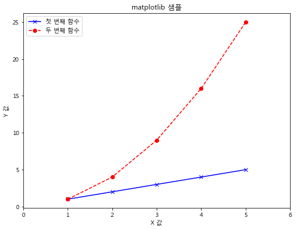

```python
# plot()의 세 번째 매개변수로 계열 스타일을 나타내는 문자열을 지정합니다.
# 'b'는 파란색, 'x'는 × 표시 마커, '-'는 마커를 실선으로 연결하라는 의미입니다.
# 키워드 매개변수 label로 지정한 계열의 이름은 범례로 사용됩니다.
plt.plot([1, 2, 3, 4, 5], [1, 2, 3, 4, 5],   'bx-', label='첫 번째 함수')

# 'r'은 붉은색,'o'는 ○ 표시 마커, '--'는 점선을 의미합니다.
plt.plot([1, 2, 3, 4, 5], [1, 4, 9, 16, 25], 'ro--', label='두 번째 함수')
# xlabel() 함수로 X축의 레이블을 지정합니다.
plt.xlabel('X 값')
# ylabel() 함수로 Y축의 레이블을 지정합니다.
plt.ylabel('Y 값')
# title() 함수로 그래프의 제목을 지정합니다.
plt.title('matplotlib 샘플')
# legend() 함수로 범례를 출력합니다. loc='best'는 적당한 위치에 출력하라는 의미입니다.
plt.legend(loc='best')

# X축 범위를 0~6으로 지정합니다. ylim() 함수를 사용하면 Y축 범위를 지정할 수 있습니다.
plt.xlim(0, 6)

# 그래프를 그리고 파일로 저장합니다.
plt.savefig('advanced_graph.png', dpi=300)
plt.show()
```

#### c5-12_plot_historical_data

> 데이터 시각화

```
from datetime import datetime
import pandas as pd
import matplotlib

matplotlib.use('Agg')
matplotlib.rcParams['font.sans-serif'] = 'NanumGothic,AppleGothic'
import matplotlib.pyplot as plt

def main():
    # 1981년과 2014년 사이의 환율과 고용률을 출력해 봅니다.
    # 조금 이해하기 쉽게 Pandas 대신 기본 숫자 비교와 문자열 비교를 사용해 봤습니다.
    # 환율 정보 읽어 들이기
    df_exchange = pd.read_csv('data/DEXKOUS.csv', header=1,
        names=['DATE', 'DEXKOUS'], skipinitialspace=True, index_col=0)
    years = {}
    output = []
    for index in df_exchange.index:
        year = int(index.split('-')[0])
        if (year not in years) and (1981 < year < 2014):
            if df_exchange.DEXKOUS[index] != ".":
                years[year] = True
                output.append([year, float(df_exchange.DEXKOUS[index])])
    df_exchange = pd.DataFrame(output)

    # 고용률 통계를 구합니다.
    df_jobs = pd.read_excel('data/gugik.xlsx')
    output = []
    stacked = df_jobs.stack()[7]
    for index in stacked.index:
        try:
            if 1981 <= int(index) <= 2014:
                output.append([int(index), float(stacked[index])])
        except:
            pass
    s_jobs = pd.DataFrame(output)

    # 첫 번째 그래프 그리기
    plt.subplot(2, 1, 1)
    plt.plot(df_exchange[0], df_exchange[1], label='원/달러')
    plt.xlim(1981, 2014) # X축의 범위를 설정합니다.
    plt.ylim(500, 2500)
    plt.legend(loc='best')

    # 두 번째 그래프 그리기
    print(s_jobs)
    plt.subplot(2, 1, 2) # 3 1 の3 のサブプロットを作成。
    plt.plot(s_jobs[0], s_jobs[1], label='고용률(%)')
    plt.xlim(1981, 2014) # X축의 범위를 설정합니다.
    plt.ylim(0, 100) # Y축의 범위를 설정합니다.
    plt.legend(loc='best')
    plt.savefig('historical_data.png', dpi=300) # 이미지를 저장합니다.

if __name__ == '__main__':
    main()
```

```python
import platform

import numpy as np
import pandas as pd
import matplotlib.pyplot as plt

from matplotlib import font_manager, rc
font_name = font_manager.FontProperties(fname="c:/Windows/Fonts/malgun.ttf").get_name()
rc('font', family=font_name)

%matplotlib inline
plt.rcParams["figure.figsize"] = [8,6]
```

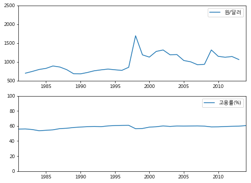

```python
# 1981년과 2014년 사이의 환율과 고용률을 출력해 봅니다.
# 조금 이해하기 쉽게 Pandas 대신 기본 숫자 비교와 문자열 비교를 사용해 봤습니다.
# 환율 정보 읽어 들이기
df_exchange = pd.read_csv('data/DEXKOUS.csv', header=1,
    names=['DATE', 'DEXKOUS'], skipinitialspace=True, index_col=0)
years = {}
output = []
for index in df_exchange.index:
    year = int(index.split('-')[0])
    if (year not in years) and (1981 < year < 2014):
        if df_exchange.DEXKOUS[index] != ".":
            years[year] = True
            output.append([year, float(df_exchange.DEXKOUS[index])])
df_exchange = pd.DataFrame(output)

# 고용률 통계를 구합니다.
df_jobs = pd.read_excel('data/gugik.xlsx')
output = []
stacked = df_jobs.stack()[7]
for index in stacked.index:
    try:
        if 1981 <= int(index) <= 2014:
            output.append([int(index), float(stacked[index])])
    except:
        pass
s_jobs = pd.DataFrame(output)

# 첫 번째 그래프 그리기
plt.subplot(2, 1, 1)
plt.plot(df_exchange[0], df_exchange[1], label='원/달러')
plt.xlim(1981, 2014) # X축의 범위를 설정합니다.
plt.ylim(500, 2500)
plt.legend(loc='best')

# 두 번째 그래프 그리기
# print(s_jobs)
plt.subplot(2, 1, 2) # 3 1 の3 のサブプロットを作成。
plt.plot(s_jobs[0], s_jobs[1], label='고용률(%)')
plt.xlim(1981, 2014) # X축의 범위를 설정합니다.
plt.ylim(0, 100) # Y축의 범위를 설정합니다.
plt.legend(loc='best')
plt.savefig('historical_data.png', dpi=300) # 이미지를 저장합니다.
plt.show()
```

### 열린 데이터 수집과 활용

> Open Data : 정부, 자치단체, 기업 등이 보유하고 있는 데이터를 공개해서 자유롭게 활용할 수 있게 하는 것
> - 공공 데이터 포털 : https://www.data.go.kr/
> - 서울 데이터 열린광장 : http://data.seoul.go.kr/

### 웹 페이지 자동 조작

> 브라우저를 조작하는 것처럼 실제로 웹페이지에 조작을 지시해서 크롤링하는 방법
> - 자동 조작을 할때는 Requests 모듈의 Session 객체를 활용해도 좋다.
> - RoboBrowser는 내부적으로 BeautifulSoup를 사용한다.

#### c5-21_robobrowser_google

> RoboBrowser로 구글 검색
> - 구글 메인 페이지 오픈 : https://www.google.co.kr/search?q=검색어
> - 검색 키워드 입력
> - 검색 버튼 클릭
> - 검색 결과 확인

```python
! pip install robobrowser
```

[output not shown]

[output not shown]

```python
from robobrowser import RoboBrowser

# RoboBrowser 객체를 생성합니다.
# 키워드 매개변수 parser는 BeautifulSoup()의 두 번째 매개변수와 같습니다.
# browser = RoboBrowser(parser='html.parser')
browser = RoboBrowser(parser='lxml')

# open() 메서드로 구글 메인 페이지를 엽니다.
browser.open('https://www.google.co.kr/')

# 키워드를 입력합니다.
form = browser.get_form(action='/search')
# form['q'] = 'Python'
form['q'] = 'BigData'
browser.submit_form(form, list(form.submit_fields.values())[0])

# 검색 결과 제목을 추출합니다.
# select() 메서드는 BeautifulSoup의 select() 메서드와 같습니다.
for a in browser.select('h3 > a'):
    print(a.text)
    print(a.get('href'))
    print()
```

```
Azure 빅데이터 분석 | 관계형 데이터 분석 및 시각화
http://www.google.co.kr/aclk?sa=l&ai=DChcSEwjM0f7CzdTeAhXRjY8KHV8xCqQYABAAGgJzYg&sig=AOD64_3RzYtaQj8EcTlKS9aM4UZlsnRAPA&ved=0ahUKEwjU_PjCzdTeAhXSc94KHR0ECIkQ0QwIFA&adurl=

SQL 데이터베이스
http://www.google.co.kr/aclk?sa=l&ai=DChcSEwjM0f7CzdTeAhXRjY8KHV8xCqQYABABGgJzYg&sig=AOD64_1uRTUwQCMZmkammEJPyjlRQWkX6A&ved=0ahUKEwjU_PjCzdTeAhXSc94KHR0ECIkQqyQIFigA&adurl=

Microsoft Azure란?
http://www.google.co.kr/aclk?sa=l&ai=DChcSEwjM0f7CzdTeAhXRjY8KHV8xCqQYABACGgJzYg&sig=AOD64_21OI-l216QZV0q3uHJhLWxZOZCYQ&ved=0ahUKEwjU_PjCzdTeAhXSc94KHR0ECIkQqyQIFygB&adurl=

SAP 코리아 공식 홈페이지 | IoT 활용 정보 수집 솔루션 | SAP.com
http://www.google.co.kr/aclk?sa=L&ai=DChcSEwjM0f7CzdTeAhXRjY8KHV8xCqQYABADGgJzYg&sig=AOD64_1KcESSy8g5bFnXnGb3EYg4mMJU6g&ved=0ahUKEwjU_PjCzdTeAhXSc94KHR0ECIkQ0QwIGQ&adurl=

빅 데이터 - 위키백과, 우리 모두의 백과사전
/url?q=https://ko.wikipedia.org/wiki/%25EB%25B9%2585_%25EB%258D%25B0%25EC%259D%25B4%25ED%2584%25B0&sa=U&ved=0ahUKEwjU_PjCzdTeAhXSc94KHR0ECIkQFggfMAA&usg=AOvVaw3GJJrPym269g_eHdgxtvGP

Big data - Wikipedia
/url?q=https://en.wikipedia.org/wiki/Big_data&sa=U&ved=0ahUKEwjU_PjCzdTeAhXSc94KHR0ECIkQFggoMAE&usg=AOvVaw0rnwW8hhtigIjSj4AWaEi-

BigData 관련 이미지
/search?q=BigData&inlang=ko&sa=G&hl=ko&gbv=1&ie=UTF-8&prmd=ivnspb&tbm=isch&tbo=u&source=univ&ved=0ahUKEwjU_PjCzdTeAhXSc94KHR0ECIkQsAQIMQ

What Is Big Data? | SAS US
/url?q=https://www.sas.com/en_us/insights/big-data/what-is-big-data.html&sa=U&ved=0ahUKEwjU_PjCzdTeAhXSc94KHR0ECIkQFgg7MAY&usg=AOvVaw3p0iZsXlky44IYhNhNUmyx

빅 데이터 | 빅 데이터란 무엇인가? | 오라클 | Oracle 대한민국
/url?q=https://www.oracle.com/kr/big-data/&sa=U&ved=0ahUKEwjU_PjCzdTeAhXSc94KHR0ECIkQFgg_MAc&usg=AOvVaw1SJ6x6p9gafw8ZdFNkc52y

What is Big Data? | Oracle
/url?q=https://www.oracle.com/big-data/guide/what-is-big-data.html&sa=U&ved=0ahUKEwjU_PjCzdTeAhXSc94KHR0ECIkQFghCMAg&usg=AOvVaw16XQ-SqczNsSSzkAKER4T8

What is Big Data ? - Definition from WhatIs.com
/url?q=https://searchdatamanagement.techtarget.com/definition/big-data&sa=U&ved=0ahUKEwjU_PjCzdTeAhXSc94KHR0ECIkQFghFMAk&usg=AOvVaw1zOVsdy3FjTMkLs7T7dmvg

Big Data Analytics | IBM Analytics
/url?q=https://www.ibm.com/analytics/hadoop/big-data-analytics&sa=U&ved=0ahUKEwjU_PjCzdTeAhXSc94KHR0ECIkQFghIMAo&usg=AOvVaw0kSMIlMhR4DHEy-c6KUMiK

빅데이터(Big data) - YouTube
/url?q=https://www.youtube.com/watch%3Fv%3DX4hMFym0-uo&sa=U&ved=0ahUKEwjU_PjCzdTeAhXSc94KHR0ECIkQtwIITDAL&usg=AOvVaw0ueKbxjVbkbqZy97loJnwN

What is Big Data? Webopedia Definition
/url?q=https://www.webopedia.com/TERM/B/big_data.html&sa=U&ved=0ahUKEwjU_PjCzdTeAhXSc94KHR0ECIkQFghPMAw&usg=AOvVaw00LxO-QvFRPt3XLoqJhhZP
```

#### c5-22_naver_order_history

> 네이버페이지 주문 이력 추출
> - 로그인이 필요한 웹사이트에서 데이터 크롤링 할때 RoboBrowser 등을 활용해야 한다.
> - 네이버페이 주문 이력 페이지는 내부적으로 자바스크립트를 사용해 과거의 주문 이력을 가져온다.

```
import time
import sys
import os
from robobrowser import RoboBrowser

# 인증 정보를 환경변수에서 추출합니다.
NAVER_ID       = os.environ['NAVER_ID']
NAVER_PASSWORD = os.environ['NAVER_PASSWORD']

# from bigpycraft.oauth import naver_key
# NAVER_ID        = naver_key.NAVER_ID
# NAVER_PASSWORD  = naver_key.NAVER_PW

# RoboBrowser 객체를 생성합니다.
browser = RoboBrowser(
    # Beautiful Soup에서 사용할 파서를 지정합니다.
    parser='html.parser',
    # 일반적인 웹 브라우저의 User-Agent(FireFox)를 사용합니다.
    user_agent='Mozilla/5.0 (Macintosh; Intel Mac macOS 10.10; rv:45.0) Gecko/20100101 Firefox/45.0')

def main():
    # 로그인 페이지를 엽니다.
    print('Accessing to sign in page....', file=sys.stderr)
    browser.open('https://nid.naver.com/nidlogin.login')

    # 로그인 페이지에 들어가졌는지 확인합니다.
    assert '네이버 : 로그인' in browser.parsed.title.string

    # name='frmNIDLogin'이라는 입력 양식을 채웁니다.
    # 입력 양식의 name 속성은 개발자 도구로 확인할 수 있습니다.
    form = browser.get_form(attrs={'name': 'frmNIDLogin'})

    # name='id'라는 입력 양식을 채웁니다.
    form['id'] = NAVER_ID
    # name='pw'라는 입력 양식을 채웁니다.
    form['pw'] = NAVER_PASSWORD

    # 입력 양식을 전송합니다.
    # 로그인 때 로그인을 막는 것을 회피하고자 몇 가지 추가 정보를 전송합니다.
    print('Signing in...', file=sys.stderr)
    browser.submit_form(form, headers={
        'Referer': browser.url,
        'Accept-Language': 'ko,en-US;q=0.7,en;q=0.3',
    })

    # 주문 이력 페이지를 엽니다.
    browser.open('https://order.pay.naver.com/home?tabMenu=SHOPPING&frm=s_order')

    # 문제가 있을 경우 HTML 소스코드를 확인할 수 있게 출력합니다.
    # print(browser.parsed.prettify())
    # 주문 이력 페이지가 맞는지 확인합니다.
    assert '네이버페이' in browser.parsed.title.string
    # 주문 이력을 출력합니다.
    print_order_history()

def print_order_history():
    """
    주문 이력을 출력합니다.
    """
    # 주문 이력을 순회합니다: 클래스 이름은 개발자 도구로 확인합니다.
    for item in browser.select('.p_info'):
        # 주문 이력 저장 전용 dict입니다.
        order = {}
        # 주문 이력의 내용을 추출합니다.
        name_element = item.select_one('span')
        date_element = item.select_one('.date')
        price_element = item.select_one('em')
        # 내용이 있을 때만 저장합니다.
        if name_element and date_element and price_element:
            name = name_element.get_text().strip()
            date = date_element.get_text().strip()
            price = price_element.get_text().strip()
            order[name] = {
                'date': date,
                'price': price
            }
            print(order[name]['date'], '-', order[name]['price'] + '원')

if __name__ == '__main__':
    main()
```

### 자바스크립트를 이용한 페이지 스크레이핑

> 자바스크립트를 해석할 때는 Selenium과 WebBrowser를 조합하는 것이 일반적
> - Selenium : 다양한 브라우저를 자동 조작하는 도구
> - 웹 애플리케이션 자동 테스트 도구로 개발됐지만, 자바스크립트를 활요한 웹페이지 크롤링에도 자주 사용된다.
> - 화면이 없는 웹브라우저(Headless Browser) 중 대표적인 것이 PhantomJS 이다.
> - 가능하면 구글크롭 웹브라우저를 사용하기를 강추한다.

#### c5-23_selenium_google

> Selenium으로 구글 검색

```python
from selenium import webdriver
from selenium.webdriver.common.keys import Keys

# PhantomJS 모듈의 WebDriver 객체를 생성합니다.
# driver = webdriver.PhantomJS()
driver_path = "../driver/chromedriver.exe"
driver = webdriver.Chrome(executable_path=driver_path)

# Google 메인 페이지를 엽니다.
driver.get('https://www.google.co.kr/')

# 타이틀에 'Google'이 포함돼 있는지 확인합니다.
assert 'Google' in driver.title

# 검색어를 입력하고 검색합니다.
input_element = driver.find_element_by_name('q')
input_element.send_keys('Python')
input_element.send_keys(Keys.RETURN)

# 타이틀에 'Python'이 포함돼 있는지 확인합니다.
assert 'Python' in driver.title

# 스크린샷을 찍습니다.
driver.save_screenshot('search_results.png')

# 검색 결과를 출력합니다.
for a in driver.find_elements_by_css_selector('h3 > a'):
    print(a.text)
    print(a.get_attribute('href'))
    print()
```

```
Download Python
https://www.python.org/downloads/

Documentation
https://www.python.org/doc/

Python For Beginners
https://www.python.org/about/gettingstarted/

Python 3.7.0
https://www.python.org/downloads/release/python-370/

Python Docs
https://docs.python.org/

Python 3.7.1
https://www.python.org/downloads/release/python-371/
```

### 추출한 데이터 활용

> - 지도로 시각화
> - 구글 BigQuery를 사용해 대량의 데이터를 빠르게 처리

#### 지도로 시각화

> - Google Maps JavaScript API를 사용해 위치 정보를 지도에 시각적으로 출력  
>   Developer Guide : https://developers.google.com/maps/documentation/geocoding/intro
> - 주소를 입력하면 위도,경도를 알려주는 지오코딩 API를 사용  
>   DashBoard :https://console.developers.google.com/projectselector/apis/api/geocoding_backend  
>   - 프로젝트 생성  
>   - 프로젝트에 사용자 인증 정보 추가

```
import time
import sys
import os
import json
import dbm
from urllib.request import urlopen
from urllib.parse import urlencode
from SPARQLWrapper import SPARQLWrapper

def main():
    features = []  # 박물관 정보 저장을 위한 리스트
    for museum in get_museums():
        # 레이블이 있는 경우에는 레이블, 없는 경우에는 s를 추출합니다.
        label = museum.get('label', museum['s'])
        address = museum['address']
        lng, lat = geocode(address)

        # 값을 출력해 봅니다.
        print(label, address, lng, lat)
        # 위치 정보를 추출하지 못 했을 경우 리스트에 추가하지 않습니다.
        if lng is None:
            continue

        # features에 박물관 정보를 GeoJSON Feature 형식으로 추가합니다.
        features.append({
            'type': 'Feature',
            'geometry': {'type': 'Point', 'coordinates': [lng, lat]},
            'properties': {'label': label, 'address': address},
        })

    # GeoJSON FeatureCollection 형식으로 dict를 생성합니다.
    feature_collection = {
        'type': 'FeatureCollection',
        'features': features,
    }
    # FeatureCollection을 .geojson이라는 확장자의 파일로 저장합니다.
    with open('museums.geojson', 'w') as f:
        json.dump(feature_collection, f)

def get_museums():
    """
    SPARQL을 사용해 DBpedia에서 박물관 정보 추출하기
    """
    print('Executing SPARQL query...', file=sys.stderr)

    # SPARQL 엔드 포인트를 지정해서 인스턴스를 생성합니다.
    sparql = SPARQLWrapper('http://ko.dbpedia.org/sparql')

    # 한국의 박물관을 추출하는 쿼리입니다.
    sparql.setQuery('''
    SELECT * WHERE {
        ?s rdf:type dbpedia-owl:Museum .
        ?s prop-ko:소재지 ?address .
        OPTIONAL { ?s rdfs:label ?label . }
    } ORDER BY ?s
    ''')

    # 반환 형식을 JSON으로 지정합니다.
    sparql.setReturnFormat('json')

    # query()로 쿼리를 실행한 뒤 convert()로 파싱합니다.
    response = sparql.query().convert()
    print('Got {0} results'.format(len(response['results']['bindings']), file=sys.stderr))
    # 쿼리 결과를 반복 처리합니다.
    for result in response['results']['bindings']:
        # 다루기 쉽게 dict 형태로 변환해서 yield합니다.
        yield {name: binding['value'] for name, binding in result.items()}

# Google Geolocation API
GOOGLE_GEOCODER_API_URL = 'https://maps.googleapis.com/maps/api/geocode/json'
# DBM(파일을 사용한 Key-Value 데이터베이스)로 지오코딩 결과를 캐시합니다.
# 이 변수는 dict처럼 다룰 수 있습니다.
geocoding_cache = dbm.open('geocoding.db', 'c')

def geocode(address):
    """
    매개변수로 지정한 주소를 지오코딩해서 위도와 경도를 반환합니다.
    """
    if address not in geocoding_cache:
        # 주소가 캐시에 존재하지 않는 경우 지오코딩합니다.
        print('Geocoding {0}...'.format(address), file=sys.stderr)
        time.sleep(1)
        url = GOOGLE_GEOCODER_API_URL + '?' + urlencode({
            'key': os.environ['GOOGLE_API_ID'],
            'language': 'ko',
            'address': address,
        })
        response_text = urlopen(url).read()
        # API 응답을 캐시에 저장합니다.
        # 문자열을 키와 값에 넣으면 자동으로 bytes로 변환합니다.
        geocoding_cache[address] = response_text

    # 캐시 내의 API 응답을 dict로 변환합니다.
    # 값은 bytes 자료형이므로 문자열로 변환합니다.
    response = json.loads(geocoding_cache[address].decode('utf-8'))
    try:
        # JSON 형식에서 값을 추출합니다.
        lng = response['results'][0]['geometry']['location']['lng']
        lat = response['results'][0]['geometry']['location']['lat']
        # float 형태로 변환한 뒤 튜플을 반환합니다.
        return (float(lng), float(lat))
    except:
        return (None, None)

if __name__ == '__main__':
    main()
```

The BigpyCraft find the information to design valuable society with Technology & Craft.

< The End >